# Tutoriel R

Ce tutoriel a pour but de guider les personnes souhaitant utiliser R pour participer au challenge.

Il comporte cinq etapes :

1. Import des donnees
2. Analyse descriptive
3. Preparation des donnees
4. Creation d’un modele en cross validation
5. Calcul des predictions et soumission

## Import des donnees

Avant de rentrer dans le vif du sujet, installons quelques packages necessaires pour ce tutoriel :

```r
if (!require(Hmisc)){install.packages("Hmisc")} ; library(Hmisc)
if (!require(randomForest)){install.packages("randomForest")} ; library("randomForest")
if (!require(ggplot2)){install.packages("randomForest")} ; library("ggplot2")
if (!require(dplyr)){install.packages("dplyr")} ; library("dplyr")
```

Le datasets sont sous format `.csv`. Vous pouvez les importer dans l’espace de travail R avec le code ci-dessous. Pensez a changer le chemin du dossier contenant les data : `dossier_data`.

```r
dossier_data = "/home/ubunty/Dropbox/FrenchData/Meilleur DS/tutoriel/data"
chemin_train = paste0(dossier_data, "/boites_medicaments_train.csv")
chemin_test = paste0(dossier_data, "/boites_medicaments_test.csv")
train = read.table(chemin_train, sep = ";", header = T, fill = T, quote = "", encoding = 'UTF-8')
test  = read.table(chemin_test,  sep = ";", header = T, fill = T, quote = "", encoding = 'UTF-8')
```

On est maintenant pret a attaquer les choses serieuses ! :)

## Analyse descriptive

### Structure des datasets

Le dataset `train` comporte les caracteristiques et prix de 8564 boites de medicaments. C’est ce dataset que nous allons utiliser pour creer un modele. Chaque boite de medicament est decrite par une observation de 41 variables. Ces variables sont decrites dans le fichier `Description.pdf` present dans la cle usb.

Le dataset `test` comporte les caracteristiques des 3671 boites de medicaments dont il faut predire le prix. A la difference de `train`, le prix des boites de medicaments n’est bien sur pas inclus et une colonne `id` a ete rajoutee pour identifier les boites de medicaments pendant l’etape de soumission des predictions sur Datascience.net

### Distribution des donnees

On remarque que la variable a predire `prix` a une tres grande dispersion. Visualisons sa distribution avec un histogramme :

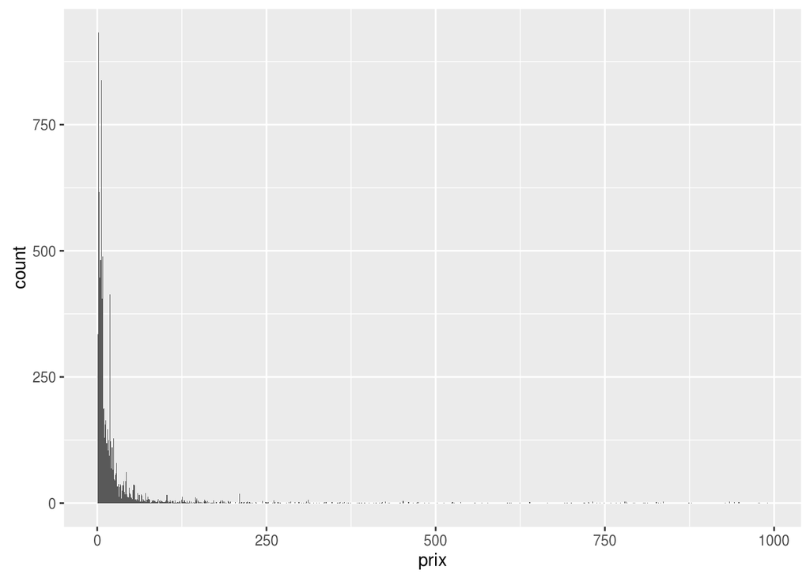

```r
ggplot(train, aes(prix)) + geom_histogram(binwidth = 1)
```

Essayons de reduire la dispersion en prenant le log du prix

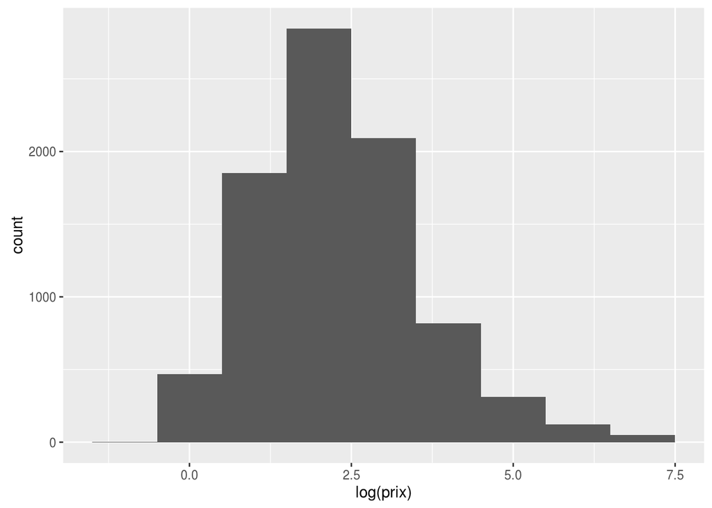

```r
ggplot(train, aes(log(prix))) + geom_histogram(binwidth = 1)
```

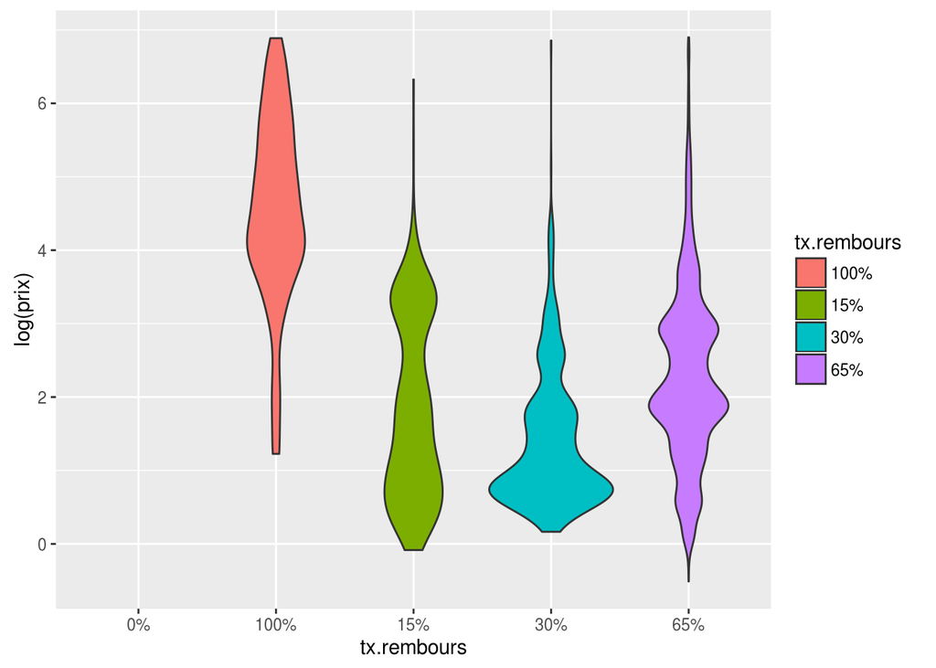

```r
# Influence sur le prix de la feature tx rembour
ggplot(train, aes(x = tx.rembours, y = log(prix), fill = tx.rembours)) + geom_violin()
```

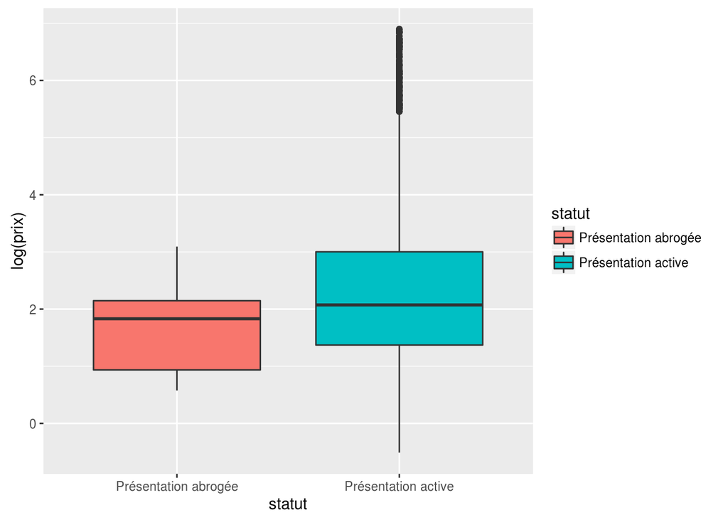

```r
# Influence sur le prix de la feature statut
ggplot(train, aes(x = statut, y = log(prix), fill = statut)) + geom_boxplot()
```

## Preparation des donnees

Pour faciliter la preparation de donnees, il est conseille de concatener les datasets `train` et `test` pour n’avoir a modifier qu’un dataset, quitte a les separer de nouveau par la suite.

```r
# Cree une variable categorie pour pouvoir separer les datasets apres la preparation des donnees
train$categorie = 'train'
test$categorie  = 'test'

full = bind_rows(train, test) # Combine train et test pour avoir un seul dataset a manipuler
```

Certaines variables categorielles se sont transformees en texte lors de concatenation des deux data sets car certaines modalites etaient presentes dans un dataset mais inconnu dans l’autre. Corrigons cela:

```r
to_factor = c('etat.commerc' ,'tx.rembours', 'forme.pharma', 'voies.admin', 'statut.admin', 'titulaires', 'substances')
full[,to_factor] = lapply(full[,to_factor] , factor)
```

### Regroupement de modalites rares

Certaines variables categorielles presentent beaucoup de modalites ce qui peut poser des problemes lors de l’utilisation de certains algorithmes de machine learning. Un moyen de regler ce probleme est de combiner les occurrences rares dans un meme groupe appelle “OTHERS”.

Pour ce faire nous utilisons la fonction `combine.levels()` pour creer cinq nouvelles variables qui sont des versions combinees des variables `libelle`, `titulaires`, `substances`, `forme.pharma` et `voies.admin`

Le niveau de regroupement choisit dans cette exemple est 0.01, ce qui signifie que toutes les modalites avec une frequence inferieur a 1% seront regroupes dans “OTHERS”

```r
full$libelle_combined      = combine.levels(full$libelle,      minlev=.01)
full$titulaires_combined   = combine.levels(full$titulaires,   minlev=.01)
full$substances_combined   = combine.levels(full$substances,   minlev=.01)
full$forme.pharma_combined = combine.levels(full$forme.pharma, minlev=.01)
full$voies.admin_combined  = combine.levels(full$voies.admin,  minlev=.01)
```

### Split train / test

Nous avons plus haut fusionne `train` et `test` dans `full` pour gagner du temps lors de la creation de variables (un seul data set a modifier).

On peut maintenant les separer de nouveau en utilisant la variable `categorie`.

```r
train = full[full$categorie == 'train',]
test  = full[full$categorie == 'test',]
```

## Creation d’un modele en cross validation

Il est maintenant temps de creer un modele. Dans ce tutoriel nous allons construire une [Foret Aleatoire](https://fr.wikipedia.org/wiki/For%C3%AAt_d'arbres_d%C3%A9cisionnels).

Pour ce faire nous utilisons toutes les variables dont nous disposons a l’exception des variables categorielles avec beaucoup de modalites que l’on a remplace plus haut par des versions combinees.

Pour eviter le [surapprentissage](https://fr.wikipedia.org/wiki/Surapprentissage) et estimer les vraies performances de notre modele nous allons utiliser le critere de [validation croisee](https://fr.wikipedia.org/wiki/Validation_crois%C3%A9e), methode k-fold.

```r
K = 5 # on partitionne l'echantillon en 5
set.seed(123) #
train$cv_id = sample(1:K, nrow(train), replace = T)

# on definit l'erreur MAPE
mape_error = function(y, ypred){mean(abs((y - ypred)/y))*100}

mape_vector = c()
for(i in 1:K){
  train_cv = train[train$cv_id != i, ]
  test_cv  = train[train$cv_id == i, ]

  rf = randomForest(data  = train_cv,
                  log(prix) ~ nb_plaquette + nb_ampoule + nb_flacon + nb_tube + nb_stylo + nb_seringue +
                    nb_pilulier + nb_sachet + nb_comprime + nb_gelule + nb_film + nb_poche +
                    nb_capsule + nb_ml + statut + etat.commerc + date.declar.annee + date.amm.annee +
                    agrement.col + tx.rembours + forme.pharma_combined + voies.admin_combined +
                    statut.admin + substances_combined + libelle_combined + titulaires_combined,
                  ntree = 10)

  mape        = mape_error(y = test_cv$prix, ypred = exp(predict(rf, test_cv))); print(mape)
  mape_vector = append(mape_vector, mape)
}
```

```
## [1] 57.02179
## [1] 60.96224
## [1] 59.66053
## [1] 58.18062
## [1] 64.84626
```

```r
print(mean(mape_vector))
```

```
## [1] 60.13429
```

Cela veut dire que notre modele predit les prix des medicaments avec 60% d’erreur en moyenne. Par exemple, si un medicament coute reellement 10 euros, notre prediction sera de 16 euros (ou 4 euros).

#### Importance des variables

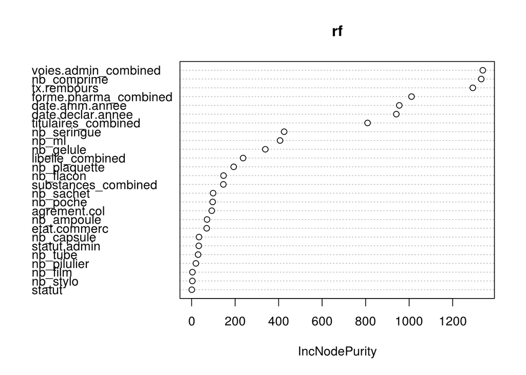

```r
varImpPlot(rf,type=2)
```

Les trois variables qui sont le plus importantes dans le modele sont :

- la voie d’administration du comprime
- le nombre de comprime
- le taux de remboursement associe au medicament

## Calcul des predictions et soumission

Maintenant que nous avons cree un modele predictif, il est temps de predire les prix des boites de medicaments de l’echantillon test :

```r
# on entraine de nouveau le modele, cette fois sur l'intégralite des donnees
rf = randomForest(data  = train,
                  log(prix) ~ nb_plaquette + nb_ampoule + nb_flacon + nb_tube + nb_stylo + nb_seringue +
                    nb_pilulier + nb_sachet + nb_comprime + nb_gelule + nb_film + nb_poche +
                    nb_capsule + nb_ml + statut + etat.commerc + date.declar.annee + date.amm.annee +
                    agrement.col + tx.rembours + forme.pharma_combined + voies.admin_combined +
                    statut.admin + substances_combined + libelle_combined + titulaires_combined,
                  ntree = 10)
prix = exp(predict(rf, test)) # Predit le prix des boites de medicaments de l'echantillon de test
soumission = data.frame(id = test$id, prix) # Cree un data.frame au bon format pour la soumission
write.table(soumission, file = 'soumission.csv', sep = ';', row.names = F) # Sauvegarde la soumission
```

Vous etes maintenant pret a faire votre premiere soumission en uplodant le fichier `soumission.csv` sur Datascience.net